# Linear Algebra: an Overview [1]

This notebook serves as an introduction to linear algebra using Python. Engage with the code by adjusting parameters and exploring its functions to deepen your understanding. Should you have questions or require clarification, do not hesitate to reach out.

## Concepts of Linear Algebra

### Useful Libraries

```python
import matplotlib.pyplot as plt
import numpy             as np

from mpl_toolkits.mplot3d.art3d import Poly3DCollection
from scipy.linalg               import eig
```

### Vector Space

```python
x_column   = np.array([[-1], [0], [0.4], [10], [np.pi]]) # Column vector in R^5
x_row      = np.array([[-1, 0, 0.4, 10, np.pi]])         # Corresponding row vector
x_column_T = x_column.T                                  # Corresponding row vector using transpose

# Displaying the results
print('Column vector:')
print(x_column)
print('\nRow vector:')
print(x_row)
print('\nColumn vector transposed:')
print(x_column_T)
```

```
Column vector:
[[-1.        ]
 [ 0.        ]
 [ 0.4       ]
 [10.        ]
 [ 3.14159265]]

Row vector:
[[-1.          0.          0.4        10.          3.14159265]]

Column vector transposed:
[[-1.          0.          0.4        10.          3.14159265]]
```

### Basic Vector Operations

```python
# Define column vectors in R^5
x = np.array([-1, 0, 0.4, 10, np.pi])
y = np.array([0, 10, -0.4, -1, 3])

lamda = 0.11      # Real scalar in R
c     = x + y     # Sum of two vectors in R^5
d     = lamda * x # Scalar multiple of a vector in R^5

# Displaying the results
print('Vector x:\t', x)
print('Vector y:\t', y)
print('Scalar lamda:\t', lamda)
print('x + y:\t\t', c)
print('lamda * x:\t', d)
```

```
Vector x:	 [-1.          0.          0.4        10.          3.14159265]
Vector y:	 [ 0.  10.  -0.4 -1.   3. ]
Scalar lamda:	 0.11
x + y:		 [-1.         10.          0.          9.          6.14159265]
lamda * x:	 [-0.11        0.          0.044       1.1         0.34557519]
```

### Important Vectors

```python
f = np.array([0, 0, 1, 0, 0]) # Standard basis 𝑒3 in R^5
g = np.ones(5)                # Column vector of ones in R^5
h = np.zeros(5)               # Column vector of zeros in R^5

# Displaying the results
print('Standard basis:\t', f)
print('All ones:\t', g)
print('All zeros:\t', h)
```

```
Standard basis:	 [0 0 1 0 0]
All ones:	 [1. 1. 1. 1. 1.]
All zeros:	 [0. 0. 0. 0. 0.]
```

### Matrix Space

```python
A = np.array([[4, -1, 0], [-1, np.pi, 10]]) # Define a real-valued matrix A in R^{2x3}
B = A.T                                     # Transpose of A to get matrix B in R^{3x2}

# Displaying the matrices
print('Matrix A:')
print(A)
print('\nMatrix B (transpose of A):')
print(B)
```

```
Matrix A:
[[ 4.         -1.          0.        ]
 [-1.          3.14159265 10.        ]]

Matrix B (transpose of A):
[[ 4.         -1.        ]
 [-1.          3.14159265]
 [ 0.         10.        ]]
```

### Important Matrices

```python
I = np.eye(3, 5)     # Identity matrix in R^{3x5} [notice that this matrix can be used to retrieve the standard bases]
J = np.zeros((5, 3)) # Zeros matrix in R^{5x3}
K = np.ones((6, 6))  # Ones matrix in R^{6x6}

# Displaying the matrices
print('Identity matrix:')
print(I)
print('\nZeros matrix:')
print(J)
print('\nOnes matrix:')
print(K)
```

```
Identity matrix:
[[1. 0. 0. 0. 0.]
 [0. 1. 0. 0. 0.]
 [0. 0. 1. 0. 0.]]

Zeros matrix:
[[0. 0. 0.]
 [0. 0. 0.]
 [0. 0. 0.]
 [0. 0. 0.]
 [0. 0. 0.]]

Ones matrix:
[[1. 1. 1. 1. 1. 1.]
 [1. 1. 1. 1. 1. 1.]
 [1. 1. 1. 1. 1. 1.]
 [1. 1. 1. 1. 1. 1.]
 [1. 1. 1. 1. 1. 1.]
 [1. 1. 1. 1. 1. 1.]]
```

### Dot Product

```python
# Define column vectors x and y in R^3
x = np.array([-1, 0.1, np.pi])
y = np.array([0, 2, 0.3])

z_dot_product             = np.dot(x, y) # Calculate the dot product of x and y using np.dot
z_dot_product_alternative = x @ y        # Alternatively, use the @ operator for dot product

# Display the results
print('Vector x:\t\t\t', x)
print('Vector y:\t\t\t', y)
print('Dot product (using np.dot):\t', z_dot_product)
print('Dot product (using @ operator):\t', z_dot_product_alternative)
```

```
Vector x:			 [-1.          0.1         3.14159265]
Vector y:			 [0.  2.  0.3]
Dot product (using np.dot):	 1.142477796076938
Dot product (using @ operator):	 1.142477796076938
```

### Vector Norms

Also known as $l_p$ norms. Notice how the values decrease as $p$ increases.

```python
x = np.random.rand(5) # Generate a random vector x in R^5

# Display the results
print(f'Random vector x: {x}\n')
[print(f'l_{i + 1} norm of x:\t\t{np.linalg.norm(x, i + 1)}') for i in range(10)]
print(f'l_inf norm of x:\t{np.linalg.norm(x, np.inf)}')
```

```
Random vector x: [0.43708824 0.71746819 0.88530565 0.21570394 0.79721364]

l_1 norm of x:		3.05277964873668
l_2 norm of x:		1.4736521279127217
l_3 norm of x:		1.1848574147129909
l_4 norm of x:		1.0722496582133314
l_5 norm of x:		1.0140743389917317
l_6 norm of x:		0.979224827151816
l_7 norm of x:		0.9563783081122994
l_8 norm of x:		0.9404785071815713
l_9 norm of x:		0.9289404454462779
l_10 norm of x:		0.9203081381556143
l_inf norm of x:	0.8853056517077345
```

### Matrix Norms

```python
A = np.random.rand(5, 3) # Generate a random matrix A in R^{5x3}

# Calculate the spectral norm, 1-norm, inf-norm, and frobenius norm of A
b_spectral_norm  = np.linalg.norm(A, 2)
c_1_norm         = np.linalg.norm(A, 1)
d_infinity_norm  = np.linalg.norm(A, np.inf)
e_frobenius_norm = np.linalg.norm(A, 'fro')

# Display the results
print('Random matrix A:')
print(A)
print('\nSpectral norm of A:\t', b_spectral_norm)
print('1-norm of A:\t\t', c_1_norm)
print('inf-norm of A:\t\t', d_infinity_norm)
print('Frobenius norm of A:\t', e_frobenius_norm)
```

```
Random matrix A:
[[0.3647405  0.24450127 0.91209795]
 [0.67139985 0.224112   0.13627266]
 [0.63259974 0.57414245 0.18500187]
 [0.47487561 0.81229876 0.69132714]
 [0.41225556 0.42721026 0.32375644]]

Spectral norm of A:	 1.8782801278395589
1-norm of A:		 2.555871261143026
inf-norm of A:		 1.9785015058661313
Frobenius norm of A:	 2.03197240180481
```

### Solving Linear Equations

The function `np.linalg.solve` solves linear equations using LAPACK [Linear Algebra PACKage] routines [2] that use $LU$ decomposition with partial pivoting and row interchanges [3], which is much faster than computing inverses.

```python
A = np.array([[2, 1], [5, 3]]) # Coefficient matrix
b = np.array([1, 2])           # Right-hand side
x = np.linalg.solve(A, b)      # Solve for x in Ax = b

print('Solution to Ax = b:', x) # Display the results
```

```
Solution to Ax = b: [ 1. -1.]
```

### Inverse and Pseudo-inverse

```python
A            = np.array([[2, 1], [5, 3]]) # Create a square matrix
A_inv        = np.linalg.inv(A)           # Calculate the inverse
A_pseudo_inv = np.linalg.pinv(A)          # Calculate the pseudo-inverse

# Display the results
print('Original matrix:')
print(A)
print("\nInverse:")
print(A_inv)
print("\nPseudo-inverse:")
print(A_pseudo_inv)
```

```
Original matrix:
[[2 1]
 [5 3]]

Inverse:
[[ 3. -1.]
 [-5.  2.]]

Pseudo-inverse:
[[ 3. -1.]
 [-5.  2.]]
```

### Eigen/Spectral Decomposition

```python
A               = np.random.rand(5, 5)              # Generate a random square matrix A in R^{5x5} with random entries
L, W, V         = eig(A, left = True, right = True) # Eigen decomposition Av = Lv and (w.T)A = L(w.T)

# Display the results
print('Random square matrix A:')
print(A)
print('\nEigen decomposition Av = Lv and (w.T)A = L(w.T):')
print('Eigenvalues:')
print(L)
print('\nLeft eigenvectors:')
print(W)
print('\nRight eigenvectors:')
print(V)
```

```
Random square matrix A:
[[0.8932966  0.45282265 0.36566497 0.00881553 0.44327841]
 [0.09954157 0.94588855 0.94002498 0.58760723 0.52970619]
 [0.96261601 0.58199552 0.79279289 0.05939403 0.2199229 ]
 [0.56420436 0.82604279 0.0547052  0.97303312 0.80147121]
 [0.3208708  0.52758568 0.93229637 0.50868777 0.42811888]]

Eigen decomposition Av = Lv and (w.T)A = L(w.T):
Eigenvalues:
[ 2.74036   +0.j          1.00770919+0.j         -0.02089465+0.34428413j
 -0.02089465-0.34428413j  0.32685016+0.j        ]

Left eigenvectors:
[[-0.4596902 +0.j          0.64178006+0.j         -0.63170669+0.j
  -0.63170669-0.j          0.55032634+0.j        ]
 [-0.53394184+0.j          0.02294653+0.j         -0.14640081-0.03094337j
  -0.14640081+0.03094337j -0.46617829+0.j        ]
 [-0.52752528+0.j          0.46617529+0.j          0.54456807+0.26452388j
   0.54456807-0.26452388j -0.48280619+0.j        ]
 [-0.30276895+0.j         -0.59388954+0.j          0.1139737 +0.17332598j
   0.1139737 -0.17332598j  0.07415464+0.j        ]
 [-0.36556677+0.j         -0.13254291+0.j          0.0110926 -0.41094253j
   0.0110926 +0.41094253j  0.49113949+0.j        ]]

Right eigenvectors:
[[-0.30888212+0.j          0.31026575+0.j         -0.32112105-0.06187647j
  -0.32112105+0.06187647j  0.34953053+0.j        ]
 [-0.52185555+0.j         -0.25549229+0.j          0.13859625-0.41128887j
   0.13859625+0.41128887j -0.80745345+0.j        ]
 [-0.37444264+0.j          0.45758844+0.j          0.0093209 +0.35691348j
   0.0093209 -0.35691348j  0.10592801+0.j        ]
 [-0.55098567+0.j         -0.79287212+0.j         -0.46160695+0.19740289j
  -0.46160695-0.19740289j  0.36639099+0.j        ]
 [-0.43412685+0.j         -0.02062692+0.j          0.57022989+0.j
   0.57022989-0.j          0.28352114+0.j        ]]
```

### Singular Value Decomposition

```python
A               = np.random.rand(5, 5) # Generate a random square matrix A in R^{5x5} with random entries
U, S, V_T       = np.linalg.svd(A)     # Perform SVD
A_reconstructed = U @ np.diag(S) @ V_T # Reconstruct the original matrix

# Display the results
print('Random square matrix A:')
print(A)
print('\nSingular value decomposition A = US(V.T):')
print('Singular values:', S)
print('\nLeft singular vectors:')
print(U)
print('\nRight singular vectors:')
print(V_T)
print('\nReconstructed matrix:')
print(A_reconstructed)
```

```
Random square matrix A:
[[0.54507266 0.10888492 0.66770098 0.84383544 0.82635158]
 [0.20988294 0.48496274 0.28872736 0.87402098 0.66010815]
 [0.43101926 0.1280712  0.84323557 0.96338147 0.34364795]
 [0.496449   0.73858452 0.68138546 0.16802926 0.12675549]
 [0.3725026  0.17783032 0.62913034 0.90750959 0.55495563]]

Singular value decomposition A = US(V.T):
Singular values: [2.75705868 0.82044771 0.53275276 0.33354778 0.00935693]

Left singular vectors:
[[-0.51833673 -0.2350247   0.06226531 -0.78827102 -0.22548227]
 [-0.42181842 -0.14829821 -0.80381593  0.32216302 -0.2239817 ]
 [-0.49130256 -0.04158911  0.58065137  0.49938775 -0.41273235]
 [-0.30309344  0.94394051 -0.06864311 -0.10097988  0.04692412]
 [-0.46920402 -0.17325616  0.09019474  0.12350999  0.85231454]]

Right singular vectors:
[[-0.32936357 -0.22894899 -0.50194151 -0.63695291 -0.42596679]
 [ 0.2765849   0.68686099  0.36489009 -0.44686102 -0.34480898]
 [ 0.21590459 -0.64445595  0.58017283 -0.0381096  -0.44722353]
 [-0.45248776  0.24507754 -0.00993224  0.57750659 -0.63370286]
 [-0.75077325  0.02044192  0.5274569  -0.24421305  0.31316268]]

Reconstructed matrix:
[[0.54507266 0.10888492 0.66770098 0.84383544 0.82635158]
 [0.20988294 0.48496274 0.28872736 0.87402098 0.66010815]
 [0.43101926 0.1280712  0.84323557 0.96338147 0.34364795]
 [0.496449   0.73858452 0.68138546 0.16802926 0.12675549]
 [0.3725026  0.17783032 0.62913034 0.90750959 0.55495563]]
```

### Symmetric Matrix, Trace, and Determinant

```python
A       = np.random.rand(5, 5) # Generate a random square matrix A in R^{5x5} with random entries
B       = 0.5 * (A + A.T)      # Make a symmetric matrix B
B_trace = np.trace(B)          # Compute the trace of B
B_det   = np.linalg.det(B)     # Compute the determinant of B

# Display the results
print('Random square matrix A:')
print(A)
print('\nSymmetric matrix B:')
print(B)
print('\nTrace of B:\t\t', B_trace)
print('Determinant of B:\t', B_det)
```

```
Random square matrix A:
[[0.65668062 0.40152043 0.02255261 0.80307654 0.45529925]
 [0.16087064 0.43485765 0.26740823 0.0314879  0.07877773]
 [0.64471248 0.56871998 0.47943541 0.88634095 0.4488305 ]
 [0.54469606 0.28753323 0.18928733 0.68736046 0.22221986]
 [0.0493979  0.03626296 0.14480577 0.95558066 0.96123289]]

Symmetric matrix B:
[[0.65668062 0.28119553 0.33363255 0.6738863  0.25234858]
 [0.28119553 0.43485765 0.4180641  0.15951057 0.05752034]
 [0.33363255 0.4180641  0.47943541 0.53781414 0.29681813]
 [0.6738863  0.15951057 0.53781414 0.68736046 0.58890026]
 [0.25234858 0.05752034 0.29681813 0.58890026 0.96123289]]

Trace of B:		 3.2195670305846287
Determinant of B:	 -0.009958184122829259
```

### Gradient Vector: Numerical Computation

```python
f       = lambda x, y: np.exp(-x**2 - y**2)                       # Define the bivariate function f(x, y)
grad    = lambda x, y, h: np.array([(f(x + h, y) - f(x, y)) / h,
                                    (f(x, y + h) - f(x, y)) / h]) # Define the gradient function
f_value = f(2, 3)                                                 # Compute the function value at (2, 3)
g       = grad(2, 3, 0.002)                                       # Compute the numerical gradient at (2, 3)

# Display the results
print('Function Value at (2, 3):\t', f_value)
print('Numerical Gradient at (2, 3):\t', g)
```

```
Function Value at (2, 3):	 2.2603294069810542e-06
Numerical Gradient at (2, 3):	 [-9.00973323e-06 -1.34853958e-05]
```

### Hessian Matrix: Numerical Computation

```python
f       = lambda x, y: np.exp(-x**2 - y**2)                                                           # Define the bivariate function f(x, y)
grad    = lambda x, y, h: np.array([(f(x + h, y) - f(x, y)) / h,
                                    (f(x, y + h) - f(x, y)) / h])                                     # Define the gradient function
hess    = lambda x, y, h: np.array([[(f(x + h, y) - 2 * f(x, y) + f(x - h, y)) / h**2,
                                     (f(x + h, y + h) - f(x + h, y) - f(x, y + h) + f(x, y)) / h**2],
                                    [(f(x + h, y + h) - f(x + h, y) - f(x, y + h) + f(x, y)) / h**2,
                                     (f(x, y + h) - 2 * f(x, y) + f(x, y - h)) / h**2]])              # Define the hessian function
f_value = f(2, 3)                                                                                     # Compute the function value at (2, 3)
g       = grad(2, 3, 0.002)                                                                           # Compute the numerical gradient at (2, 3)
H       = hess(2, 3, 0.002)                                                                           # Compute the numerical hessian at (2, 3)

# Display the results
print('Function value at (2, 3):\t', f_value)
print('Numerical gradient at (2, 3):\t', g)
print('\nNumerical hessian at (2, 3):')
print(H)
```

```
Function value at (2, 3):	 2.2603294069810542e-06
Numerical gradient at (2, 3):	 [-9.00973323e-06 -1.34853958e-05]

Numerical hessian at (2, 3):
[[3.16446690e-05 5.37531470e-05]
 [5.37531470e-05 7.68518599e-05]]
```

## Visualizations of Linear Algebra

### Plotting Vectors

The function `np.random.rand` generates an array of the specified shape, filled with random samples from a uniform distribution over $[0, 1)$ [4]. Consequently, each execution of the cell below will plot a distinct vector on the $1 \times 1$ grid.

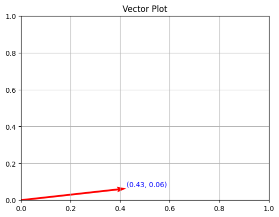

```python
vector = np.random.rand(2) # Create a 2D vector with random components

plt.figure()                                                          # Plot the vector
plt.quiver(0, 0, vector[0], vector[1], angles = 'xy',
           scale_units = 'xy', scale = 1, color = 'r')                # Use quiver to represent the vector as an arrow
plt.text(vector[0], vector[1], f'({vector[0]:.2f}, {vector[1]:.2f})',
         fontsize = 10, color = 'b', va = 'bottom', ha = 'left')      # Add text annotation next to the arrowhead with the vector coordinates
plt.xlim(0, 1)                                                        # Set the x-axis limits to ensure proper visualization
plt.ylim(0, 1)                                                        # Set the y-axis limits to ensure proper visualization
plt.title('Vector Plot')                                              # Set the title of the plot
plt.grid(True)                                                        # Display the grid for reference
plt.show()                                                            # Show the plot
```